# M.Gameel

### unemployment with date broken by region

in the bivariate section we couldn’t get clear view of employment by date let’s break it by some regions(stores)

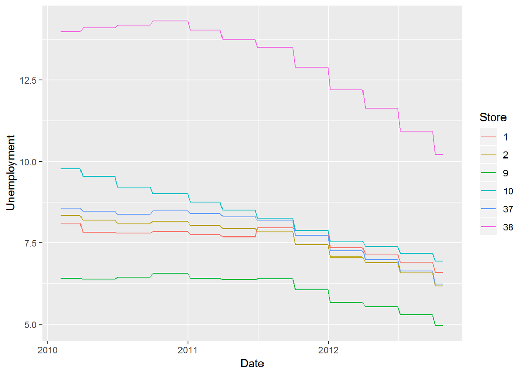

the unemployment is decreasing through time from 2010 to 2013 in our selected regions

### CPI with date broken by region

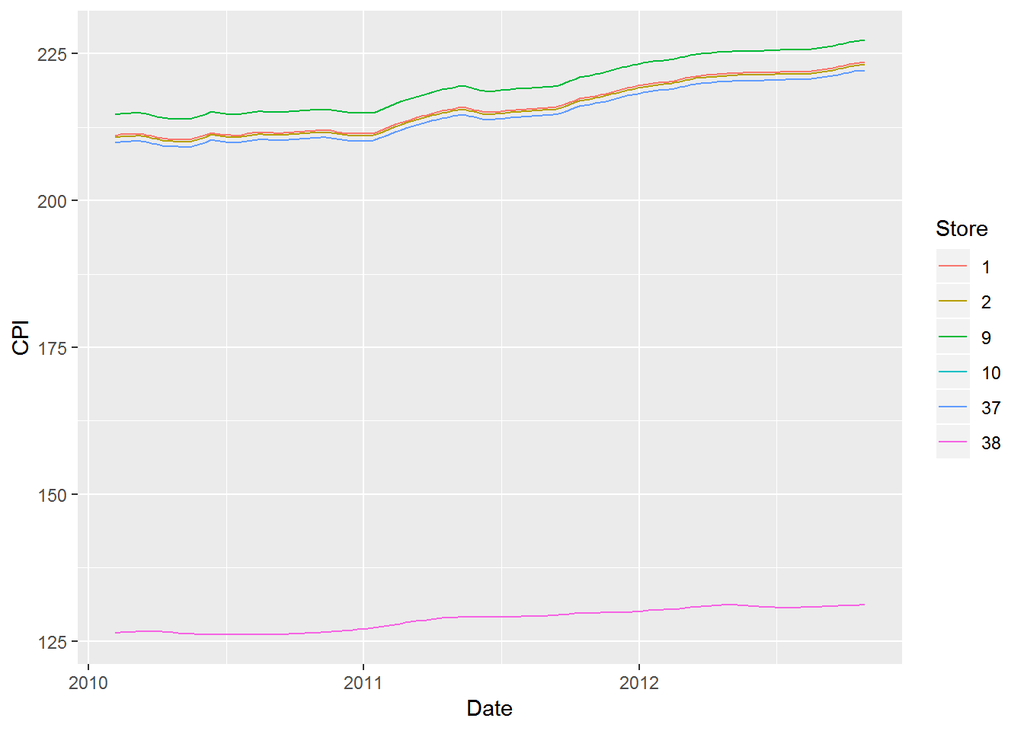

the CPI is increasing through time from 2010 to 2013 in our selected regions

# Multivariate Analysis

### Were there any interesting or surprising interactions between features?

YES,the relationship between unemployment ,CPI and time wasn’t clear in the previous section but when broken by region it was clear that the unemployment decreased over time and the CPI increased over time

### OPTIONAL: Did you create any models with your dataset? Discuss the strengths and limitations of your model.

```r
library(scales)
library(memisc)
test = as.Date("2012-02-03","%Y-%m-%d")
m1 <- lm(Weekly_Sales ~ Store + Date  , data = data[data$Date < test,])
m2 <- update(m1, ~ . + Store_Type)
m3 <- update(m2, ~ . + Store_Size)
m4 <- update(m3, ~ . + IsHoliday)
m5 <- update(m4, ~ . + Fuel_Price)
m6 <- update(m5, ~ . + CPI)
m7 <- update(m6, ~ . + Unemployment)
m8 <- update(m7, ~ . + Temperature)
m9 <- update(m8, ~ . + Markdown)
mtable(m1, m2, m3, m4, m5,m6,m7,m8,m9 ,sdigits = 3,summary.stats=c("R-squared"))
```

```
##
## Calls:
## m1: lm(formula = Weekly_Sales ~ Store + Date, data = data[data$Date <
##     test, ])
## m2: lm(formula = Weekly_Sales ~ Store + Date + Store_Type, data = data[data$Date <
##     test, ])
## m3: lm(formula = Weekly_Sales ~ Store + Date + Store_Type + Store_Size,
##     data = data[data$Date < test, ])
## m4: lm(formula = Weekly_Sales ~ Store + Date + Store_Type + Store_Size +
##     IsHoliday, data = data[data$Date < test, ])
## m5: lm(formula = Weekly_Sales ~ Store + Date + Store_Type + Store_Size +
##     IsHoliday + Fuel_Price, data = data[data$Date < test, ])
## m6: lm(formula = Weekly_Sales ~ Store + Date + Store_Type + Store_Size +
##     IsHoliday + Fuel_Price + CPI, data = data[data$Date < test,
##     ])
## m7: lm(formula = Weekly_Sales ~ Store + Date + Store_Type + Store_Size +
##     IsHoliday + Fuel_Price + CPI + Unemployment, data = data[data$Date <
##     test, ])
## m8: lm(formula = Weekly_Sales ~ Store + Date + Store_Type + Store_Size +
##     IsHoliday + Fuel_Price + CPI + Unemployment + Temperature,
##     data = data[data$Date < test, ])
## m9: lm(formula = Weekly_Sales ~ Store + Date + Store_Type + Store_Size +
##     IsHoliday + Fuel_Price + CPI + Unemployment + Temperature +
##     Markdown, data = data[data$Date < test, ])
##
## =========================================================================================================================================================================
##                       m1               m2               m3               m4               m5               m6               m7               m8               m9
## -------------------------------------------------------------------------------------------------------------------------------------------------------------------------
##   (Intercept)     665125.730***    665125.730***    665125.730***    734115.639***  -1041331.206***  -1131059.906**    -988003.543*     -686820.932       258529.829
##                  (189503.494)     (189503.494)     (189503.494)     (188104.868)     (278533.613)     (348127.316)     (425638.624)     (429606.862)     (448524.309)
##   Store: 2        393059.857***    393059.857***    393059.857***    393059.857***    393059.857***    393497.555***    394226.433***    393575.273***    388977.945***
##                   (25066.898)      (25066.898)      (25066.898)      (24860.501)      (24667.595)      (24690.784)      (24724.037)      (24669.578)      (24553.249)
##   Store: 3      -1143088.387***  -1143088.387***  -1143088.387***  -1143088.387***  -1143088.387***  -1147326.568***  -1149766.718***  -1145112.353***  -1127123.806***
##                   (25066.898)      (25066.898)      (25066.898)      (24860.501)      (24667.595)      (26568.097)      (26896.265)      (26855.257)      (26843.861)
##   Store: 4        526649.844***    526649.844***    526649.844***    526649.844***    526800.757***    635523.279*      638964.285*      597245.127*      295718.309
##                   (25066.898)      (25066.898)      (25066.898)      (24860.501)      (24667.601)     (254200.434)     (254286.733)     (253881.178)     (256287.077)
##   Store: 5      -1225293.838***  -1225293.838***  -1225293.838***  -1225293.838***  -1225293.838***  -1226003.843***  -1232842.182***  -1229502.169***  -1217377.163***
##                   (25066.898)      (25066.898)      (25066.898)      (24860.501)      (24667.595)      (24725.031)      (27357.252)      (27306.006)      (27223.288)
##   Store: 6         27866.265        27866.265        27866.265        27866.265        27866.265        25923.229        20974.171        24317.801        32663.132
##                   (25066.898)      (25066.898)      (25066.898)      (24860.501)      (24667.595)      (25080.697)      (26474.337)      (26425.387)      (26318.618)
```

[output cut: 80 more lines]

```
##   IsHoliday                                                           87091.731***     72816.621***     72942.046***     73294.969***     66060.716***     49381.665***
##                                                                       (9844.527)       (9908.572)       (9913.741)       (9932.832)      (10032.206)      (10265.417)
##   Fuel_Price                                                                          -88672.099***    -88933.392***    -88280.586***    -76151.015***    -57873.101***
##                                                                                       (10325.701)      (10344.495)      (10405.400)      (10705.111)      (10970.302)
##   CPI                                                                                                    1264.915         1377.917          932.981        -2626.043
##                                                                                                         (2943.494)       (2950.051)       (2945.061)       (2974.473)
##   Unemployment                                                                                                           -5166.114        -3407.427         1772.934
##                                                                                                                          (8842.635)       (8831.121)       (8817.816)
##   Temperature                                                                                                                              -782.999***      -666.824***
##                                                                                                                                            (168.420)        (168.396)
##   Markdown                                                                                                                                                     2.050***
##                                                                                                                                                               (0.295)
## -------------------------------------------------------------------------------------------------------------------------------------------------------------------------
##   R-squared            0.901            0.901            0.901            0.903            0.905            0.905            0.905            0.905            0.906
## =========================================================================================================================================================================
```

```r
predicted = predict(m9,newdata = data[data$Date >= test,])

data$predict[data$Date >= test] = predicted

#error percent
summary((data[data$Date >= test,]$predict-
           data[data$Date >= test,]$Weekly_Sales)*100/
          data[data$Date >= test,]$Weekly_Sales)
```

```
##    Min. 1st Qu.  Median    Mean 3rd Qu.    Max.
## -28.628  -2.591   3.785   4.563  10.338  60.580
```

```r
#calculate RSME
sqrt(mean((data[data$Date >= test,]$predict-
             data[data$Date >= test,]$Weekly_Sales)^2))
```

```
## [1] 119812.5
```

the r square of the model looks good . i have calculated the error percent and the RSME for the model.looks like the model is over estimating the sales in most cases

# Final Plots and Summary

### Plot One

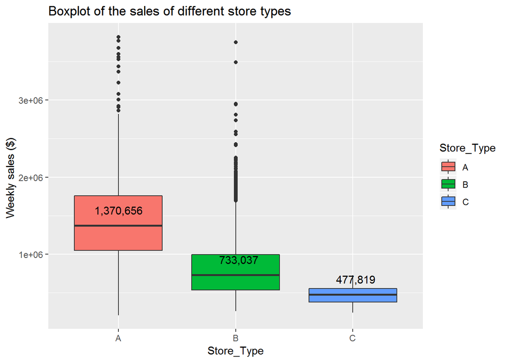

### Description One

one of the strong relationships of sales is the store type . the store of type A has a median sales higher than the B and B has a median sales higher than C.

### Plot Two

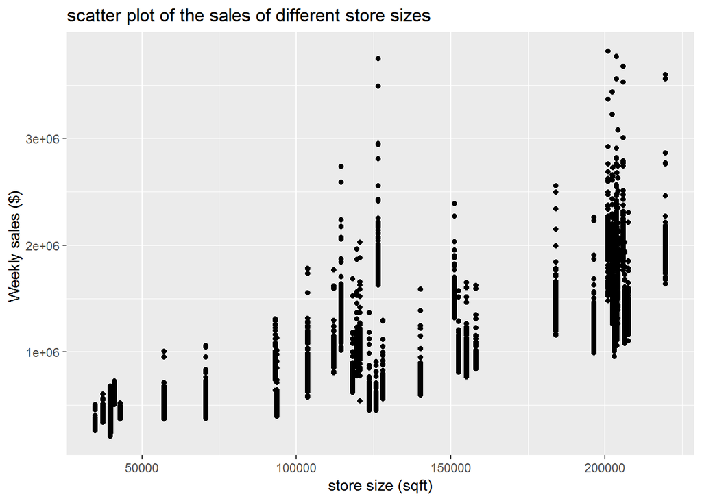

### Description Two

one of the strong relationships with sales is the store size the stores with larger size tends to have more sales

### Plot Three

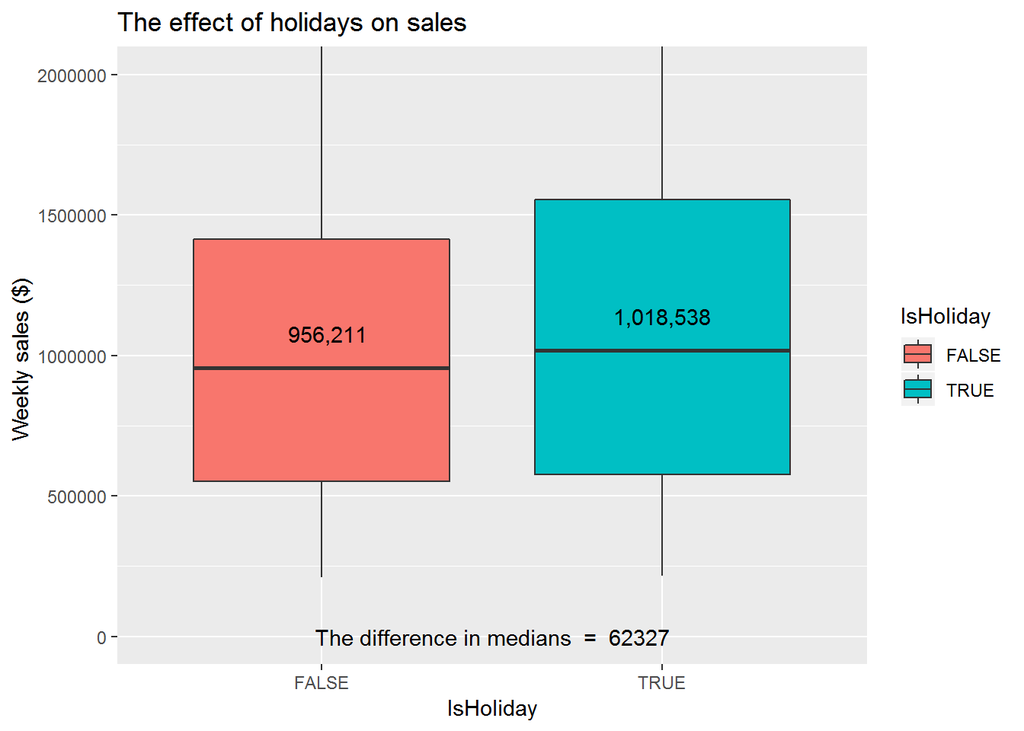

### Description Three

the holidays have a big effect on the sales . the weeks of holidays tends to have more sales than ordinary weeks with difference of nearly 62.5k

# Reflection

The exploration was really fun. I discovered that the most three factors that affect retail sales are the store size , store type and holiday weeks

Some of the struggles i went through that the bivariate exploration wasn’t enough to understand the performance of unemployment and CPI over time .When broken by region ,it was clear that the unemployment was decreasing through time and the CPI is increasing

The amount of sales in dollars is misleading because it is effected by prices or any markdowns on the goods . A future investigation with the units of goods bought will be clearer and more effected by other factors